# Benchmarking long-read DE gene and transcript analysis with edgeR

## 2.2 Filter out lowly expressed genes and transcripts

```r
#GENE
## 1. get common genes
common_genes <- Reduce(intersect, lapply(list(ill_bulk.gene.dge, ont_bulk.gene.dge, pb_bulk.gene.dge, drna_bulk.gene.dge), rownames))

ill_bulk.gene.dge <- ill_bulk.gene.dge[common_genes, ]
ont_bulk.gene.dge <- ont_bulk.gene.dge[common_genes, ]
pb_bulk.gene.dge <- pb_bulk.gene.dge[common_genes, ]
drna_bulk.gene.dge <- drna_bulk.gene.dge[common_genes, ]

## 2. filter by expression
keep <- filterByExpr(ill_bulk.gene.dge, group = ill_bulk.gene.dge$samples$group) &
          filterByExpr(ont_bulk.gene.dge, group = ont_bulk.gene.dge$samples$group) &
          filterByExpr(pb_bulk.gene.dge, group = pb_bulk.gene.dge$samples$group) &
          filterByExpr(drna_bulk.gene.dge, group = drna_bulk.gene.dge$samples$group)

#table(keep)
ill_bulk.gene.dge <- ill_bulk.gene.dge[keep, ]
ont_bulk.gene.dge <- ont_bulk.gene.dge[keep, ]
pb_bulk.gene.dge <- pb_bulk.gene.dge[keep, ]
drna_bulk.gene.dge <- drna_bulk.gene.dge[keep, ]

# Transcript
## 1. get common transcripts
common_tx <- Reduce(intersect, lapply(list(ill_bulk.tx.dge, ont_bulk.tx.dge, pb_bulk.tx.dge, drna_bulk.tx.dge), rownames))

ill_bulk.tx.dge <- ill_bulk.tx.dge[common_tx, ]
ont_bulk.tx.dge <- ont_bulk.tx.dge[common_tx, ]
pb_bulk.tx.dge <- pb_bulk.tx.dge[common_tx, ]
drna_bulk.tx.dge <- drna_bulk.tx.dge[common_tx, ]

## 2. filter by expression
keep <- filterByExpr(ill_bulk.tx.dge, group = ill_bulk.tx.dge$samples$group, min.count=5) &
          filterByExpr(ont_bulk.tx.dge, group = ont_bulk.tx.dge$samples$group, min.count=5) &
          filterByExpr(pb_bulk.tx.dge, group = pb_bulk.tx.dge$samples$group, min.count=5) &
          filterByExpr(drna_bulk.tx.dge, group = drna_bulk.tx.dge$samples$group, min.count=5)
#table(keep)

ill_bulk.tx.dge <- ill_bulk.tx.dge[keep, ]
ont_bulk.tx.dge <- ont_bulk.tx.dge[keep, ]
pb_bulk.tx.dge <- pb_bulk.tx.dge[keep, ]
drna_bulk.tx.dge <- drna_bulk.tx.dge[keep, ]
```

## 2.3 Normalisation

Next, the gene and transcript counts using `calcNormFactors` with “TMM” methods for each dataset.

```r
ill_bulk.gene.dge <- calcNormFactors(ill_bulk.gene.dge, method = "TMM")
ont_bulk.gene.dge <- calcNormFactors(ont_bulk.gene.dge, method = "TMM")
pb_bulk.gene.dge <- calcNormFactors(pb_bulk.gene.dge, method = "TMM")
drna_bulk.gene.dge <- calcNormFactors(drna_bulk.gene.dge, method = "TMM")

ill_bulk.tx.dge <- calcNormFactors(ill_bulk.tx.dge, method = "TMM")
ont_bulk.tx.dge <- calcNormFactors(ont_bulk.tx.dge, method = "TMM")
pb_bulk.tx.dge <- calcNormFactors(pb_bulk.tx.dge, method = "TMM")
drna_bulk.tx.dge <- calcNormFactors(drna_bulk.tx.dge, method = "TMM")
```

# 3 Explore the data using dimensionality reduction

Up until now, we have prepared the DGElist objects for each dataset (gene and transcript level) and normalised the counts using TMM. Let’s now explore the data using MDS plots and then proceed to differential expression analysis.

To explore the data across all datasets, we will merge the DGElist objects from each dataset (gene and transcript level) into a single DGElist object for gene-level and transcript-level counts, respectively. Please NOTE: The merged DGElist will only be used for the MDS plot. The DE analysis will be done separately for each dataset.

Now let’s create MDS plots to visualize the relationships between samples based on their gene and transcript expression profiles.

- Plot Gene-level MDS plot

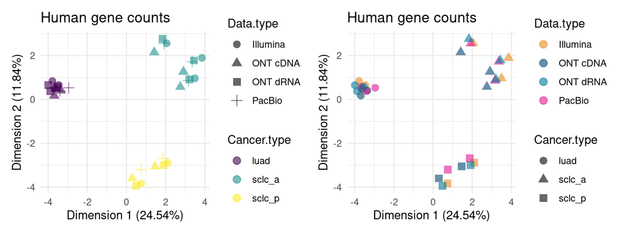

- Transcript-level MDS plot

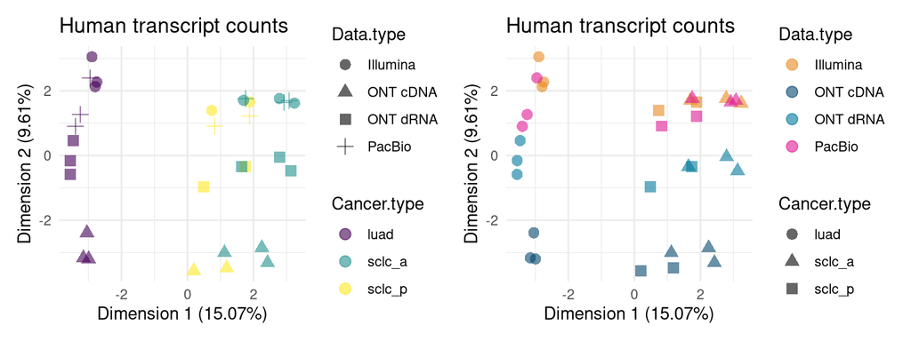

From the MDS plot, we can clearly see that samples cluster by cancer type (LUAD, SCLC type a, SCLC type p). However, at the transcript level, the samples also cluster by sequencing platform (Illumina, ONT cDNA, ONT dRNA, PacBio), suggesting that technical differences between platforms also contribute to the observed variation.

# 4 Differential gene expression

Now, let’s proceed to differential gene expression (DGE) analysis using the edgeR Quasi-Likelihood pipeline. We will perform DGE analysis separately for each dataset (Illumina, ONT cDNA, ONT dRNA, PacBio) using the filtered and normalised DGElist objects created earlier.**SCLC type A vs. LUAD** with the model:

*Model: `model.matrix(~0 + group, data = dge$samples)`*

Differential expression gene and transcript lists are defined using `DecideTests` with a log2 fold change cutoff of 0 and FDR<0.05.

Let’s first set up the workflow as a function so we can repeat it across different platforms:

```r
DGE.edgeR_human <- function(dge, norm.method = "TMM") {
  design <- model.matrix(~0 + group, data = dge$samples)
  dge <- estimateDisp(dge, design)
  qlfit <- glmQLFit(dge, design)

  contrasts <- makeContrasts(
    AvsL = groupsclc_a - groupluad,
    levels = design
  )

  AvsL.QLF.test <- glmQLFTest(qlfit, contrast = contrasts[, "AvsL"])

  list(
    AvsL.DE = AvsL.QLF.test
  )
}
```

Now, let’s apply the function to the `DGElist` objects.

```r
# DEG analsysis on human genes only
ill_bulk.dge_human.list <- DGE.edgeR_human(ill_bulk.gene.dge)
ont_bulk.dge_human.list <- DGE.edgeR_human(ont_bulk.gene.dge)
drna_bulk.deg_human.list <- DGE.edgeR_human(drna_bulk.gene.dge)
pb_bulk.dge_human.list <- DGE.edgeR_human(pb_bulk.gene.dge)
```

## 4.1 Cross-platform comparison DGE human (upset plot)

After we get the DE genes from each sequencing platform, we can overlap the DE genes and visualise them using an upset plot with `ComplexUpset`

Now we can plot the upset plot.

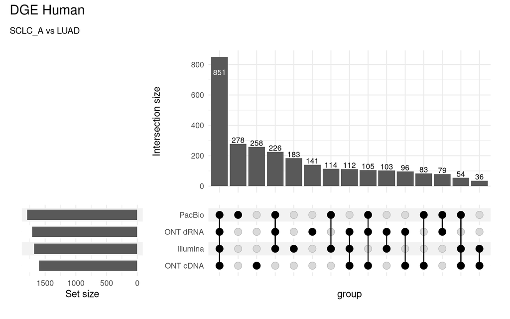

The results show that differentially expressed genes are largely consistent across platforms, with PacBio detecting the most DE genes, followed by ONT dRNA.

# 5 Differential transcript expression

The same analysis can be done at the transcript level. Since the read-to-transcript assignment is sometimes uncertain, we applied the pipeline suggested in Baldoni et al. (2024).

```r
DTE.edgeR_human <- function(dge, norm.method="TMM") {
  # Scale
  dge.scaled <- dge
  dge.scaled$counts <- dge.scaled$counts / dge.scaled$genes$Overdispersion

  # Normalisation
  if (!is.null(norm.method)) {
     dge <- calcNormFactors(dge, method = norm.method)
  }

  design <- model.matrix(~0+group, data = dge.scaled$samples)
  dge.scaled <- estimateDisp(dge.scaled, design)
  qlfit <- glmQLFit(dge.scaled, design)

  contrasts <- makeContrasts(
    AvsL = groupsclc_a - groupluad,
    levels = design
  )

  AvsL.QLF.test <- glmQLFTest(qlfit, contrast = contrasts[, "AvsL"])

  list(
    AvsL.DE = AvsL.QLF.test
  )

}
```

## 5.1 DTE edgeR+scaling

```r
# get human list
ill_bulk.scl_dte_human.list <- DTE.edgeR_human(ill_bulk.tx.dge)
ont_bulk.scl_dte_human.list <- DTE.edgeR_human(ont_bulk.tx.dge)
pb_bulk.scl_dte_human.list <- DTE.edgeR_human(pb_bulk.tx.dge)
drna_bulk.scl_dte_human.list <- DTE.edgeR_human(drna_bulk.tx.dge)
```

## 5.2 Cross-platform comparison DTE human (upset)

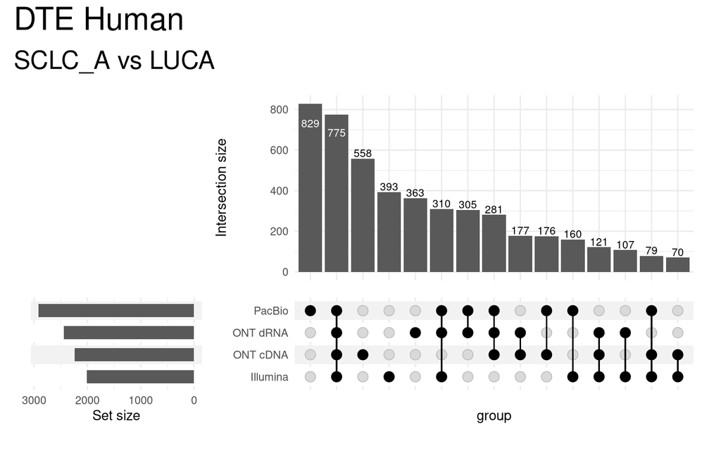

```r
# Upset plot
## SCLC_A vs LUCA (AvsL)
lst <- list(
  "Illumina" = ill_bulk.scl_dte_human.list$AvsL.DE,
  "ONT cDNA" = ont_bulk.scl_dte_human.list$AvsL.DE,
  "PacBio" = pb_bulk.scl_dte_human.list$AvsL.DE,
  "ONT dRNA" = drna_bulk.scl_dte_human.list$AvsL.DE
)
p <- complex_upset_plot(lst)$plot + ggtitle("SCLC_A vs LUCA") + theme(plot.title = element_text(size = 20))
mat.AvsL.DTE <- complex_upset_plot(lst)$matrix

p + patchwork::plot_annotation(
  title = "DTE Human",
  theme = theme(plot.title = element_text(size =25))
)
```

Here, the differential transcript expression (DTE) results visualised in the upset plots show less consistency when comparing the gene-level DE results.

# 6 References

Baldoni, Pedro L, Yunshun Chen, Soroor Hediyeh-Zadeh, Yang Liao, Xueyi Dong, Matthew E Ritchie, Wei Shi, and Gordon K Smyth. 2024. “Dividing Out Quantification Uncertainty Allows Efficient Assessment of Differential Transcript Expression with edgeR.” *Nucleic Acids Research* 52 (3): e13–13.